# Introduction to Mathematical Computations with Python

# 7. Derivative

Welcome to sympy!

sympy gives us symbolic abilities, like differentiation, integration, transforms and solving DEs.

#### Key commands and methods:

x, y = symbols('x y') # -> define x, y as symbols

f1 = x**2 + x + sin(x) # -> define a symbolic function

fd1 = diff(f1, x, 2) # -> compute second order symbolic derivative of f1 based on x

f2 = x**2 + arcsin(y) # -> define multivariable function

fd2 = diff(f1, y, 1) # -> partial differentiation

## 7.1 Symbolic differentiation

Let see what is in sympy library :

```python
import sympy

print(dir(sympy))
```

[output not shown]

```python
from sympy import * # imports all required functions, methods and types

x, y, z, t, snt = symbols('x y z t snt') # symbols

f1 = exp(x*y + t**(x*y)) + cos(t*2) + sin(y + x + t)
fd1 = diff(f1, t, 1) # first-order derivative based on x
fd1 = diff(fd1, x, 1)
fd1 = diff(fd1, y, 2)

print("\nFirst function:")
print(fd1)
print(fd1.subs(x, 3)) # string output
print(fd1.subs(x, 3.)) # float

f2 = sin(x + y) + y**3 + x*y**4
fd2 = diff(f2, y, 2) # second-order derivative based on y
print("\nSecond function:")
print(fd2)
print(fd2.subs(x, 2.).subs(y, 1.)) # getting values from the function
```

```
First function:
sin(t + x + y) + t**(2*x*y)*x**3*y**2*(t**(x*y)*log(t) + 1)*exp(t**(x*y) + x*y)*log(t)**2/t + t**(2*x*y)*x**3*y**2*exp(t**(x*y) + x*y)*log(t)**3/t + t**(2*x*y)*x**2*y*(x*y*log(t) + 2)*exp(t**(x*y) + x*y)*log(t)**2/t + t**(2*x*y)*x**2*y*exp(t**(x*y) + x*y)*log(t)**2/t + t**(x*y)*x**3*y**2*(t**(x*y)*l…
sin(t + y + 3) + 27*t**(6*y)*y**2*(t**(3*y)*log(t) + 1)*exp(t**(3*y) + 3*y)*log(t)**2/t + 27*t**(6*y)*y**2*exp(t**(3*y) + 3*y)*log(t)**3/t + 9*t**(6*y)*y*(3*y*log(t) + 2)*exp(t**(3*y) + 3*y)*log(t)**2/t + 9*t**(6*y)*y*exp(t**(3*y) + 3*y)*log(t)**2/t + 27*t**(3*y)*y**2*(t**(3*y)*log(t) + 1)**3*exp(t*…
sin(t + y + 3.0) + 27.0*t**(3.0*y)*y**2*(t**(3.0*y)*log(t) + 1)**3*exp(t**(3.0*y) + 3.0*y)/t + 81.0*t**(3.0*y)*y**2*(t**(3.0*y)*log(t) + 1)**2*exp(t**(3.0*y) + 3.0*y)*log(t)/t + 81.0*t**(3.0*y)*y**2*(t**(3.0*y)*log(t) + 1)*exp(t**(3.0*y) + 3.0*y)*log(t)**2/t + 27.0*t**(3.0*y)*y**2*exp(t**(3.0*y) + 3…

Second function:
12*x*y**2 + 6*y - sin(x + y)
29.8588799919401
```

## 7.2 Numerical differentiation

As easy as easy. there are two different ways for numerical differentiation:

```python
import numpy as np

x = np.random.randint(-3, 3, 10)
y1 = np.gradient(x, 1) # the interpolated gradient
y2 = x[0:len(x)-1] - x[1:len(x)] # normal gradient

print(x)
print(y1)
print(y2)
```

```
[-2  1 -3  2  0  2 -2 -3  0  2]
[ 3.  -0.5  0.5  1.5  0.  -1.  -2.5  1.   2.5  2. ]
[-3  4 -5  2 -2  4  1 -3 -2]
```

# 8. Integration

Integration is most cool part of sympy.

## 8.1 Integrals

Example:

```python
from sympy import * # imports all required functions, methods and types

x, y, z, t = symbols('x y z t') # symbols

f1 = (x**2)*cos(x) + exp(x*2)
I1 = integrate(f1, x) # symbolic integral based on x
print("\nFirst function integral:")
print(I1)
print(I1.subs(x, 3)) # string output
print(I1.subs(x, 3.) - I1.subs(x, 1.)) # float

f2 = sin(x + y) + y**3 + x*y**4
I2 = integrate(f2, y) # symbolic integral based on y
print("\nSecond function:")
print(I2)
print(I2.subs(x, 2.).subs(y, 1.)) # getting values from the function
```

```
First function integral:
x**2*sin(x) + 2*x*cos(x) + exp(2*x)/2 - 2*sin(x)
6*cos(3) + 7*sin(3) + exp(6)/2
192.828620146790

Second function:
x*y**5/5 + y**4/4 - cos(x + y)
1.63999249660045
```

## 8.2 Integral Transforms

### 8.2.1 Laplace transform

```python
from sympy.integrals import laplace_transform
from sympy.abc import t, s, a

F1 = t**a + sin(t) + exp(3*a*t)
L1 = laplace_transform(F1, t, s)

print(L1)
```

```
(s**(-a - 1)*gamma(a + 1) + 1/(s**2 + 1) - 1/(s*(3*a/s - 1)), 0, (re(a) > -1) & ((re(a) > -1) | (re(a) - 1 < -1)) & ((re(a) > -1) | Eq(Abs(arg(s)), pi/2)) & ((Abs(arg(a) + pi) <= pi/2) | (Abs(arg(a) + pi) < pi/2)))
```

### 8.2.2 Inverse Laplace transform

```python
from sympy.integrals.transforms import inverse_laplace_transform
from sympy import exp, Symbol
from sympy.abc import s, t
a = Symbol('a', positive=True)

L2 = exp(-a*s)/s**2
F2 = inverse_laplace_transform(L2, s, t)
print(F2)
```

```
(-a + t)*Heaviside(-a + t)
```

### 8.2.3 Mellin transform

```python
from sympy.integrals.transforms import mellin_transform
from sympy import exp
from sympy.abc import x, s

F1 = exp(-x) + sin(x)
M1 = mellin_transform(F1, x, s)
print(M1)
```

```
((2**s*sqrt(pi)*gamma(s/2 + 1/2) - gamma(-s/2)*gamma(s + 1))/(2*gamma(1 - s/2)), (0, 1), True)
```

### 8.2.4 Fourier and I-Fourier transform

```python
from sympy import fourier_transform, exp, inverse_fourier_transform
from sympy.abc import x, k

F1 = exp(-x*2) * Heaviside(x)
Q1 = fourier_transform(F1, x, k)
Q2 = fourier_transform(F2, x, k, noconds=False)

print(Q1)
print(Q2)
```

[output not shown]

# 9. Differential equations

## 9.0 Definition

In python-sympy, to start a DE session, at first we need to assign differential equations.

Look at this simple example:

```python
from sympy import Function, dsolve, Eq, Derivative, sin, cos, symbols
from sympy.abc import x

f = Function('f')(x) # Defining F as function of x
fp = Derivative(f, x) # F prime (1st derivative)
fz = Derivative(f, x, x) # F zegond (2nd derivative)
fy = Derivative(fz, x)

deq1 = fz + 9*f - fy
p1 = dsolve(deq1, f)

print(p1)
```

```
Eq(f(x), C1*exp(x*(-2**(2/3)*(9*sqrt(741) + 245)**(1/3) - 2*2**(1/3)/(9*sqrt(741) + 245)**(1/3) + 4)/12)*sin(2**(1/3)*sqrt(3)*x*(-2**(1/3)*(9*sqrt(741) + 245)**(1/3) + 2/(9*sqrt(741) + 245)**(1/3))/12) + C2*exp(x*(-2**(2/3)*(9*sqrt(741) + 245)**(1/3) - 2*2**(1/3)/(9*sqrt(741) + 245)**(1/3) + 4)/12)*…
```

## 9.1 ODE

Visit [https://docs.sympy.org/latest/modules/solvers/ode.html], ODE has so many properties

## 9.2 PDE

Visit [https://docs.sympy.org/latest/modules/solvers/pde.html]

### 9.3 Euler's method for numerical ODE approximation

```python
from matplotlib import pyplot as plt


def f(x, y):
    return (x + y - x * y) + (x**2) -(y**3)


def euler_ode(x0, y, h, x):
    sol = []
    xs = []
    while x0 < x:
        y = y + h * f(x0, y)
        x0 = x0 + h
        sol.append(y)
        xs.append(x0)

    return xs, sol

x0 = 0
y0 = 1
h = 0.025

# Value of x at which we need approximation
x = 10
x, y = euler_ode(x0, y0, h, x)

fig, ax = plt.subplots()
ax.plot(x, y)
```

[output not shown]

#### 9.4 Runge-Kutta's method for DE

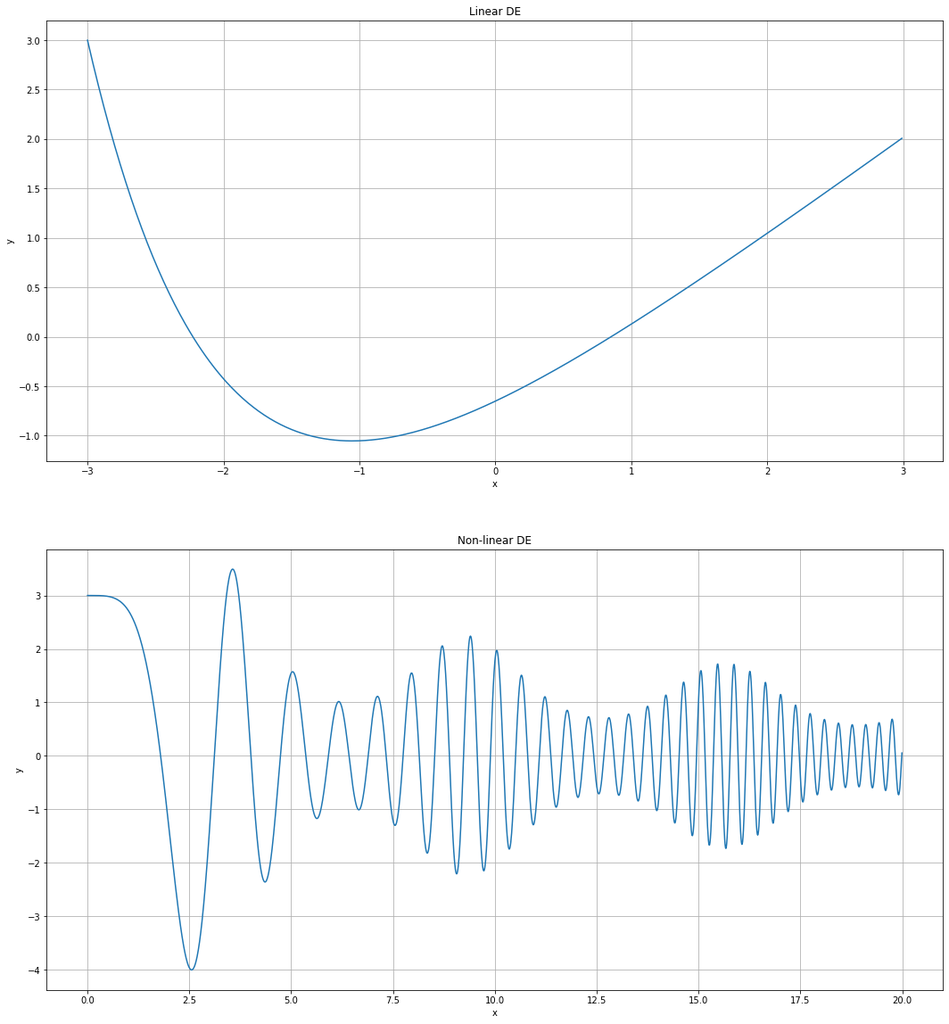

```python
from matplotlib import pyplot as plt
import numpy as np


def runge_kutta4_2(x0, y10, y20, x, h, F1, F2): # for 2nd order

    n = (int)((x - x0)/h)
    y1 = y10
    y2 = y20
    lgx = []
    lgy = []
    for i in range(1, n+1):

        lgx.append(x)
        lgy.append(y1)

        k11 = h * F1(x, y1, y2)
        k21 = h * F2(x, y1, y2)
        k12 = h * F1(x + 0.5*h, y1 + 0.5*k11, y2 + 0.5*k21)
        k22 = h * F2(x + 0.5*h, y1 + 0.5*k11, y2 + 0.5*k21)

        k13 = h * F1(x + 0.5*h, y1 + 0.5*k12, y2 + 0.5*k22)
        k23 = h * F2(x + 0.5*h, y1 + 0.5*k12, y2 + 0.5*k22)
        k14 = h * F1(x + h, y1 + k13, y2 + k23)
        k24 = h * F2(x + h, y1 + k13, y2 + k23)

        y1 += (k11 + 2*(k12 + k13) + k14)/6
        y2 += (k21 + 2*(k22 + k23) + k24)/6
        x += h

    return lgx, lgy

def runge_kutta4_1(x0, y0, x, h, F): # for 1st order

    n = (int)((x - x0)/h)
    y = y0
    lgx = []
    lgy = []
    for i in range(1, n+1):

        lgx.append(x0)
        lgy.append(y)

        k1 = h * F(x0, y)
        k2 = h * F(x0 + 0.5 * h, y + 0.5 * k1)
        k3 = h * F(x0 + 0.5 * h, y + 0.5 * k2)
        k4 = h * F(x0 + h, y + k3)

        y = y + (1.0 / 6.0)*(k1 + 2 * k2 + 2 * k3 + k4)
        x0 = x0 + h

    return lgx, lgy


def f1(x, y1, y2):
    dy1dx = y2
    return dy1dx


def f2(x, y1, y2):
    dy2dx = -y1 * x**2 + y2 * np.sin(x)
    return dy2dx


def f3(x, y):
    dydx = -y + x
    return dydx


x0 = -3
y = 3
yp = 0
x = 3
h = 0.01

# print('The value of y at x is:', runge_kutta4_1(x0, y, x, h, f3))
# print('The value of y at x is:', runge_kutta4_2(x0, y, yp, x, h, f1, f2))
x1, y1 = runge_kutta4_1(x0, y, x, h, f3)

x0 = -20
y = 3
yp = 0
x = 0
h = 0.01

x2, y2 = runge_kutta4_2(x0, y, yp, x, h, f1, f2)

# Plot em
fig, ax = plt.subplots(2, 1)
fig.set_figwidth(18)
fig.set_figheight(20)

# Interpolated plotting
ax[0].plot(x1, y1)
ax[0].set_xlabel("x")
ax[0].set_ylabel("y")
ax[0].grid()
ax[0].set_title("Linear DE")
# ax[0].set_ylim([-30, 30])

# Changes plotting
ax[1].plot(x2, y2)
ax[1].set_xlabel("x")
ax[1].set_ylabel("y")
ax[1].grid()
ax[1].set_title("Non-linear DE")
# ax[0].set_ylim([-10, 10])
fig.show()
```